# Psychology dataset

Bakki Akhil

# The given dataset is about the Psychology of people working in various sectors or companies, in various designations.

## the business here provided in the dataset gives the designation of all the people with respecitive their age and their performace is compared by providing the ranks

## The Business problem here includes finding the best peroformer or find what are the factors which can include in change in performace of an employee

## if we see in the dataset there are various factors available which being the factors effecting the performance

## The dataset and summary of the dataset is given below.

```r
data1 = read.csv("D:\\Akhil MBA\\MBA 3 Trimester\\Statistical Modeling using R\\psychology data set.csv",stringsAsFactors = TRUE)

str(data1)
```

```
## 'data.frame':    241 obs. of  11 variables:
##  $ sno                               : int  1 2 3 4 5 6 7 8 9 10 ...
##  $ Name                              : Factor w/ 233 levels "Abhay","Abhey Suhane",..: 212 166 14 221 167 22 54 121 81 49 ...
##  $ Sex                               : Factor w/ 3 levels "","F","M": 3 3 2 3 3 3 3 3 3 3 ...
##  $ Age                               : int  35 40 23 36 25 30 48 28 26 33 ...
##  $ Company                           : Factor w/ 56 levels "","Acropolis",..: 13 13 13 13 13 13 34 34 34 34 ...
##  $ Designation                       : Factor w/ 134 levels "","A/c- TVC",..: 9 1 12 84 124 81 95 48 54 134 ...
##  $ Creative.Personality              : int  99 107 104 98 103 104 84 73 55 62 ...
##  $ Block.to.creativity               : int  103 78 92 100 102 123 98 115 99 89 ...
##  $ Innovative.sponsoring.capabilities: int  126 117 112 97 125 136 111 129 109 124 ...
##  $ Social.Environment                : int  23 21 20 22 19 20 21 20 16 20 ...
##  $ Work.environment                  : int  23 22 22 18 20 21 21 21 19 20 ...
```

```r
summary(data1)
```

```
##       sno                  Name     Sex          Age
##  Min.   :  1   Ashish Vyas   :  2    :  1   Min.   :20.00
##  1st Qu.: 61   Ashok Gutpa   :  2   F: 36   1st Qu.:28.00
##  Median :121   Deepak Vyas   :  2   M:204   Median :32.00
##  Mean   :121   Jitendra      :  2           Mean   :33.74
##  3rd Qu.:181   Mayank Rathore:  2           3rd Qu.:40.00
##  Max.   :241   Pankaj Kumawat:  2           Max.   :68.00
##                (Other)       :229
##               Company          Designation  Creative.Personality
##  HDFC             :33   Asst. Prof.  : 13   Min.   : 52.00
##  Ruchi Soya       :30   Manager      : 13   1st Qu.: 82.00
##  India Bulls      :23   Asst. Manager: 10   Median : 91.00
##  Indothai         :23   RM           :  9   Mean   : 89.22
##  Medi-caps Limited:20   PROD         :  7   3rd Qu.: 99.00
##  SVIM Indore      :20   Manager      :  6   Max.   :107.00
##  (Other)          :92   (Other)      :183
##  Block.to.creativity Innovative.sponsoring.capabilities Social.Environment
##  Min.   : 78.00      Min.   : 94.0                      Min.   : 9.00
##  1st Qu.: 94.00      1st Qu.:120.0                      1st Qu.:19.00
##  Median : 99.00      Median :126.0                      Median :21.00
##  Mean   : 98.87      Mean   :126.5                      Mean   :20.87
##  3rd Qu.:103.00      3rd Qu.:134.0                      3rd Qu.:22.00
##  Max.   :136.00      Max.   :158.0                      Max.   :25.00
##
##  Work.environment
##  Min.   :12.00
##  1st Qu.:20.00
##  Median :22.00
##  Mean   :21.73
##  3rd Qu.:23.00
##  Max.   :25.00
##
```

```r
#View(data1)
dim(data1)
```

```
## [1] 241  11
```

# The Library DataExplorer is used to explore the data and find the missing values pressence in the data with the correlaiton in the data. The code for it is written below

```r
library(DataExplorer)
create_report(data1)
```

```
##
##
## processing file: report.rmd
```

[output not shown]

[output not shown]

[output not shown]

[output not shown]

[output not shown]

[output not shown]

[output not shown]

[output not shown]

```
## output file: D:/Akhil MBA/MBA 3 Trimester/Statistical Modeling using R/report.knit.md
```

[output not shown]

```
##
## Output created: report.html
```

## From the provided dataset we can check that the factor creative personality is the element which can effect in any place in an industry or organization leading us to creating a problem statement

# The problem statement here includes the null Hypothesis of how does dependent variable Creative personality of an employee varies with respective to all other independent variables like Age, Block to creativity, Innovation sponsering capabilities, social environment, work environment.

## For doing this we have omitted the missing values from the dataset using ‘na.omit’

## The final data with less missing values are used for further calculations

## The below code is used for removing missing values and stored in data2 which is further used in calculations

```r
data2 = na.omit(data1)

str(data2)
```

```
## 'data.frame':    241 obs. of  11 variables:
##  $ sno                               : int  1 2 3 4 5 6 7 8 9 10 ...
##  $ Name                              : Factor w/ 233 levels "Abhay","Abhey Suhane",..: 212 166 14 221 167 22 54 121 81 49 ...
##  $ Sex                               : Factor w/ 3 levels "","F","M": 3 3 2 3 3 3 3 3 3 3 ...
##  $ Age                               : int  35 40 23 36 25 30 48 28 26 33 ...
##  $ Company                           : Factor w/ 56 levels "","Acropolis",..: 13 13 13 13 13 13 34 34 34 34 ...
##  $ Designation                       : Factor w/ 134 levels "","A/c- TVC",..: 9 1 12 84 124 81 95 48 54 134 ...
##  $ Creative.Personality              : int  99 107 104 98 103 104 84 73 55 62 ...
##  $ Block.to.creativity               : int  103 78 92 100 102 123 98 115 99 89 ...
##  $ Innovative.sponsoring.capabilities: int  126 117 112 97 125 136 111 129 109 124 ...
##  $ Social.Environment                : int  23 21 20 22 19 20 21 20 16 20 ...
##  $ Work.environment                  : int  23 22 22 18 20 21 21 21 19 20 ...
```

```r
#View(data2)
summary(data2)
```

```
##       sno                  Name     Sex          Age
##  Min.   :  1   Ashish Vyas   :  2    :  1   Min.   :20.00
##  1st Qu.: 61   Ashok Gutpa   :  2   F: 36   1st Qu.:28.00
##  Median :121   Deepak Vyas   :  2   M:204   Median :32.00
##  Mean   :121   Jitendra      :  2           Mean   :33.74
##  3rd Qu.:181   Mayank Rathore:  2           3rd Qu.:40.00
##  Max.   :241   Pankaj Kumawat:  2           Max.   :68.00
##                (Other)       :229
##               Company          Designation  Creative.Personality
##  HDFC             :33   Asst. Prof.  : 13   Min.   : 52.00
##  Ruchi Soya       :30   Manager      : 13   1st Qu.: 82.00
##  India Bulls      :23   Asst. Manager: 10   Median : 91.00
##  Indothai         :23   RM           :  9   Mean   : 89.22
##  Medi-caps Limited:20   PROD         :  7   3rd Qu.: 99.00
##  SVIM Indore      :20   Manager      :  6   Max.   :107.00
##  (Other)          :92   (Other)      :183
##  Block.to.creativity Innovative.sponsoring.capabilities Social.Environment
##  Min.   : 78.00      Min.   : 94.0                      Min.   : 9.00
##  1st Qu.: 94.00      1st Qu.:120.0                      1st Qu.:19.00
##  Median : 99.00      Median :126.0                      Median :21.00
##  Mean   : 98.87      Mean   :126.5                      Mean   :20.87
##  3rd Qu.:103.00      3rd Qu.:134.0                      3rd Qu.:22.00
##  Max.   :136.00      Max.   :158.0                      Max.   :25.00
##
##  Work.environment
##  Min.   :12.00
##  1st Qu.:20.00
##  Median :22.00
##  Mean   :21.73
##  3rd Qu.:23.00
##  Max.   :25.00
##
```

```r
dim(data2)
```

```
## [1] 241  11
```

## The final dataset with removed missing values are used for finding multiple regression. The code for this is given below where caTools library is used for running regression model

```r
library(caTools)
set.seed(2028229)
```

# The below code is used to check the regression for the original dataset for computing the null hypothesis between the dependent variable(Creative.Personality) and the independent variables(Age, Block.to.creativity, Innovative.sponsoring.capabilities, Social.Environment, Work.environment).

```r
reg1 = lm(data2$Creative.Personality~data2$Age+
            data2$Block.to.creativity+
            data2$Innovative.sponsoring.capabilities+
            data2$Social.Environment+
            data2$Work.environment)
```

## The sunnary of the above regression is shown below

## Here in the output we can see that

## The P-value here is less than 0.05 leading to rejecting null hypothesis and accepting Alternate hypothesis, of Creative personality is dependent on changes of Age, Block.to.creativity, Innovative.sponsoring.capabilities, Social.Environment, Work.environment.

## Adjustede R square here specifies that 20.15% of change in creative personality is dependent on all other independent variables

## Multiple R square here specifies that 21.82% of chage in creative personality is dependent on all other independent variables

## Here in Intersept as p value is less than 0.05 for every one unit increase will lead to there is a degree of change of 49.66 in the Intersept, beta here being 49.66

## Here in Age as p value is greater than 0.05 there is no dependency of age in creative personality and beta here being 0.12

## Here in Block to creativity as p value is less than 0.05 for every one unit increase will lead to there is a degree of change decrease by 0.21 in the Intersept, beta here being -0.21309

## Here in Innovative.sponsoring.capabilities as p value is greater than 0.05 there is no dependency of Innovative.sponsoring.capabilities in creative personality and beta here being 0.05795

## Here in Social.Environment as p value is greater than 0.05 there is no dependency of Social.Environment in creative personality and beta here being 0.46877

## Here in Work.environment as p value is less than 0.05 for every one unit increase will lead to there is a degree of change by 1.81325 in the Intersept, beta here being 1.81325

```r
summary(reg1)
```

```
##
## Call:
## lm(formula = data2$Creative.Personality ~ data2$Age + data2$Block.to.creativity +
##     data2$Innovative.sponsoring.capabilities + data2$Social.Environment +
##     data2$Work.environment)
##
## Residuals:
##     Min      1Q  Median      3Q     Max
## -39.945  -6.866  -0.097   7.285  23.376
##
## Coefficients:
##                                          Estimate Std. Error t value Pr(>|t|)
## (Intercept)                              49.66566   12.63899   3.930 0.000112
## data2$Age                                 0.12147    0.09538   1.274 0.204089
## data2$Block.to.creativity                -0.21309    0.09078  -2.347 0.019743
## data2$Innovative.sponsoring.capabilities  0.05795    0.08296   0.698 0.485558
## data2$Social.Environment                  0.46877    0.43509   1.077 0.282397
## data2$Work.environment                    1.81325    0.44417   4.082 6.11e-05
##
## (Intercept)                              ***
## data2$Age
## data2$Block.to.creativity                *
## data2$Innovative.sponsoring.capabilities
## data2$Social.Environment
## data2$Work.environment                   ***
## ---
## Signif. codes:  0 '***' 0.001 '**' 0.01 '*' 0.05 '.' 0.1 ' ' 1
##
## Residual standard error: 11.13 on 235 degrees of freedom
## Multiple R-squared:  0.2182, Adjusted R-squared:  0.2015
## F-statistic: 13.12 on 5 and 235 DF,  p-value: 2.862e-11
```

## Here below we are spliting the data in 90:10 ratio where the 90% part is used for training and the rest 10% part is used for testing the dataset of data2

```r
split1 = sample.split(data2$sno, SplitRatio = 0.90)

datatrain1 = subset(data2, split1==TRUE)
dim(datatrain1)
```

```
## [1] 216  11
```

```r
datatest1 = subset(data2,split1==FALSE)
dim(datatest1)
```

```
## [1] 25 11
```

## Here we care forming multiple regression for training dataset taking dependent variable as Creative.Personality and independent variable are Age, Block.to.creativity, Innovative.sponsoring.capabilities, Social.Environment, Work.environment

```r
reg1 = lm(datatrain1$Creative.Personality~datatrain1$Age+
            datatrain1$Block.to.creativity+
            datatrain1$Innovative.sponsoring.capabilities+
            datatrain1$Social.Environment+
            datatrain1$Work.environment)
```

## The below code is used for finding the summary of the regression for the training dataset

## Here in the output we can see that

## The P-value here is less than 0.05 leading to rejecting null hypothesis and accepting Alternate hypothesis, of Creative personality is dependent on changes of Age, Block.to.creativity, Innovative.sponsoring.capabilities, Social.Environment, Work.environment.

## Adjustede R square here specifies that 21.42% of change in creative personality is dependent on all other independent variables

## Multiple R square here specifies that 23.25% of change in creative personality is dependent on all other independent variables

## Here in Intersept as p value is less than 0.05 for every one unit increase will lead to there is a degree of change of 45.16798 in the Intersept, beta here being 45.16798

## Here in Age as p value is greater than 0.05 there is no dependency of age in creative personality and beta here being 0.08356

## Here in Block to creativity as p value is less than 0.05 for every one unit increase will lead to there is a degree of change decrease by 0.19 in the Intersept, beta here being -0.19709

## Here in Innovative.sponsoring.capabilities as p value is greater than 0.05 there is no dependency of Innovative.sponsoring.capabilities in creative personality and beta here being 0.08179

## Here in Social.Environment as p value is greater than 0.05 there is no dependency of Social.Environment in creative personality and beta here being 0.45578

## Here in Work.environment as p value is less than 0.05 for every one unit increase will lead to there is a degree of change by 1.87247 in the Intersept, beta here being 1.87247

```r
summary(reg1)
```

```
##
## Call:
## lm(formula = datatrain1$Creative.Personality ~ datatrain1$Age +
##     datatrain1$Block.to.creativity + datatrain1$Innovative.sponsoring.capabilities +
##     datatrain1$Social.Environment + datatrain1$Work.environment)
##
## Residuals:
##     Min      1Q  Median      3Q     Max
## -39.859  -7.306  -0.595   7.185  23.569
##
## Coefficients:
##                                               Estimate Std. Error t value
## (Intercept)                                   45.16798   13.49596   3.347
## datatrain1$Age                                 0.08356    0.10056   0.831
## datatrain1$Block.to.creativity                -0.19709    0.09466  -2.082
## datatrain1$Innovative.sponsoring.capabilities  0.08179    0.08801   0.929
## datatrain1$Social.Environment                  0.45578    0.45007   1.013
## datatrain1$Work.environment                    1.87247    0.45631   4.104
##                                               Pr(>|t|)
## (Intercept)                                   0.000969 ***
## datatrain1$Age                                0.406982
## datatrain1$Block.to.creativity                0.038541 *
## datatrain1$Innovative.sponsoring.capabilities 0.353784
## datatrain1$Social.Environment                 0.312377
## datatrain1$Work.environment                   5.82e-05 ***
## ---
## Signif. codes:  0 '***' 0.001 '**' 0.01 '*' 0.05 '.' 0.1 ' ' 1
##
## Residual standard error: 11.1 on 210 degrees of freedom
## Multiple R-squared:  0.2325, Adjusted R-squared:  0.2142
## F-statistic: 12.72 on 5 and 210 DF,  p-value: 8.273e-11
```

## The below code is used to plot the multiple regression between dependent and independent variables and shows the graph of Residual vs Fitted, Normal Q-Q, Scale Location, Residual vs Leverage

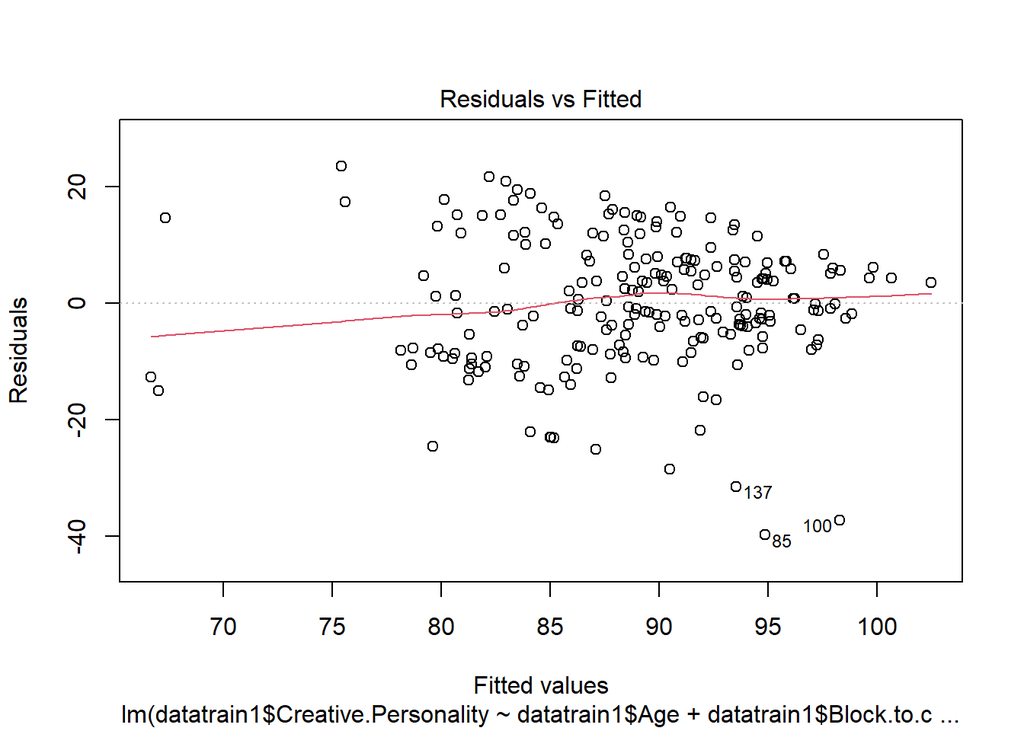

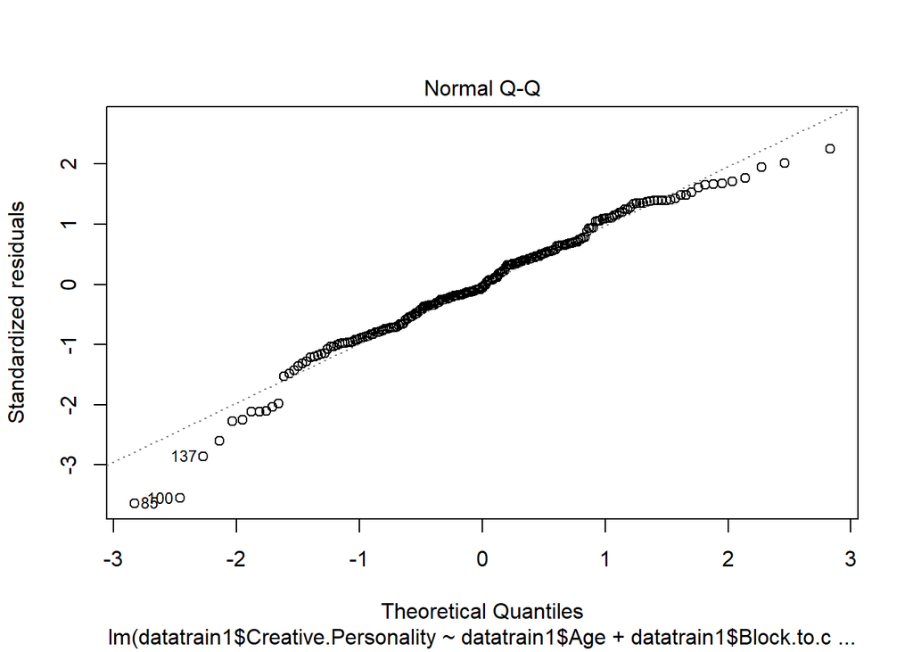

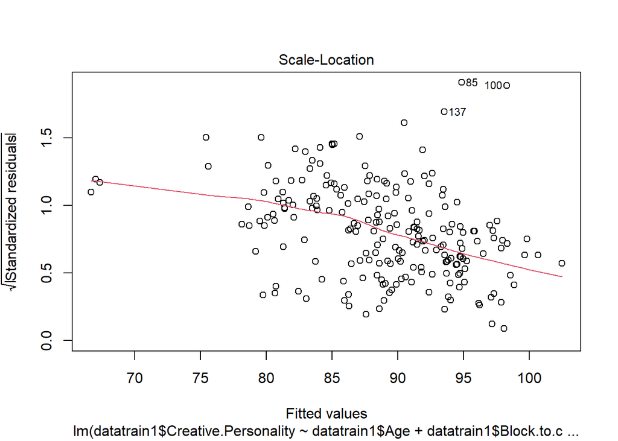

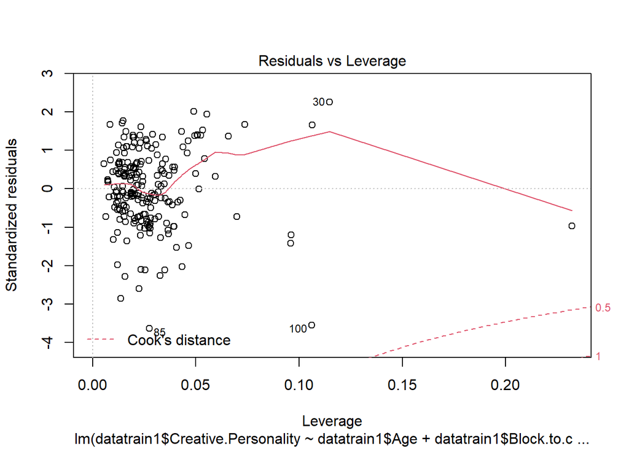

```r
plot(reg1)
```

## The below code is used to find the outliers using the graph Boxplot and here we got to know that there are 3 outliers in the code and we are removing those outliers from the dataset

```r
library(car)
```

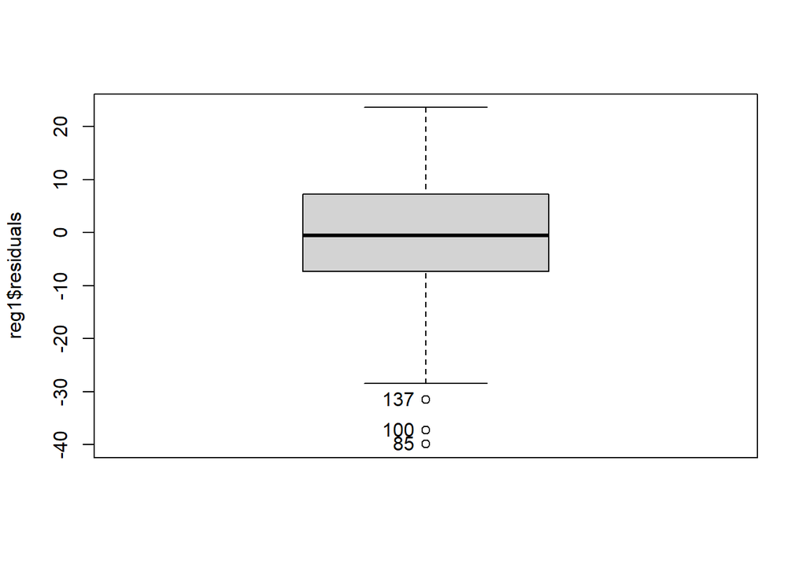

```r
out1 = Boxplot(reg1$residuals)
```

```r
out1
```

```
## [1]  85 100 137
```

```r
dim(datatrain1)
```

```
## [1] 216  11
```

```r
datatrain1 = datatrain1[-out1,]
dim(datatrain1)
```

```
## [1] 213  11
```

## Again we are doing regression after we removing the few outliers from the dataset

```r
reg1 = lm(datatrain1$Creative.Personality~datatrain1$Age+
            datatrain1$Block.to.creativity+
            datatrain1$Innovative.sponsoring.capabilities+
            datatrain1$Social.Environment+
            datatrain1$Work.environment)
```

## The below code is used for finding the summary of the regression for the training dataset

## Here in the output we can see that

## The P-value here is less than 0.05 leading to rejecting null hypothesis and accepting Alternate hypothesis, of Creative personality is dependent on changes of Age, Block.to.creativity, Innovative.sponsoring.capabilities, Social.Environment, Work.environment.

## Adjustede R square here specifies that 28.64% of change in creative personality is dependent on all other independent variables

## Multiple R square here specifies that 30.32% of change in creative personality is dependent on all other independent variables

## Here in Intersept as p value is less than 0.05 for every one unit increase will lead to there is a degree of change of 42.40892 in the Intersept, beta here being 42.40892

## Here in Age as p value is greater than 0.05 there is no dependency of age in creative personality and beta here being 0.17949

## Here in Block to creativity as p value is less than 0.05 for every one unit increase will lead to there is a degree of change decrease by 0.19631 in the Intersept, beta here being -0.19631

## Here in Innovative.sponsoring.capabilities as p value is greater than 0.05 there is no dependency of Innovative.sponsoring.capabilities in creative personality and beta here being 0.01472

## Here in Social.Environment as p value is greater than 0.05 there is no dependency of Social.Environment in creative personality and beta here being 0.47826

## Here in Work.environment as p value is less than 0.05 for every one unit increase will lead to there is a degree of change by 2.24256 in the Intersept, beta here being 2.24256

```r
summary(reg1)
```

```
##
## Call:
## lm(formula = datatrain1$Creative.Personality ~ datatrain1$Age +
##     datatrain1$Block.to.creativity + datatrain1$Innovative.sponsoring.capabilities +
##     datatrain1$Social.Environment + datatrain1$Work.environment)
##
## Residuals:
##      Min       1Q   Median       3Q      Max
## -28.4664  -7.1541  -0.6809   6.6984  22.7069
##
## Coefficients:
##                                               Estimate Std. Error t value
## (Intercept)                                   42.40892   12.44592   3.407
## datatrain1$Age                                 0.17949    0.09698   1.851
## datatrain1$Block.to.creativity                -0.19631    0.08729  -2.249
## datatrain1$Innovative.sponsoring.capabilities  0.01472    0.08185   0.180
## datatrain1$Social.Environment                  0.47826    0.41546   1.151
## datatrain1$Work.environment                    2.24256    0.42568   5.268
##                                               Pr(>|t|)
## (Intercept)                                   0.000788 ***
## datatrain1$Age                                0.065625 .
## datatrain1$Block.to.creativity                0.025571 *
## datatrain1$Innovative.sponsoring.capabilities 0.857502
## datatrain1$Social.Environment                 0.250992
## datatrain1$Work.environment                   3.45e-07 ***
## ---
## Signif. codes:  0 '***' 0.001 '**' 0.01 '*' 0.05 '.' 0.1 ' ' 1
##
## Residual standard error: 10.22 on 207 degrees of freedom
## Multiple R-squared:  0.3032, Adjusted R-squared:  0.2864
## F-statistic: 18.02 on 5 and 207 DF,  p-value: 8.005e-15
```

## The below code is used to plot the multiple regression between dependent and independent variables and shows the graph of Residual vs Fitted, Normal Q-Q, Scale Location, Residual vs Leverage

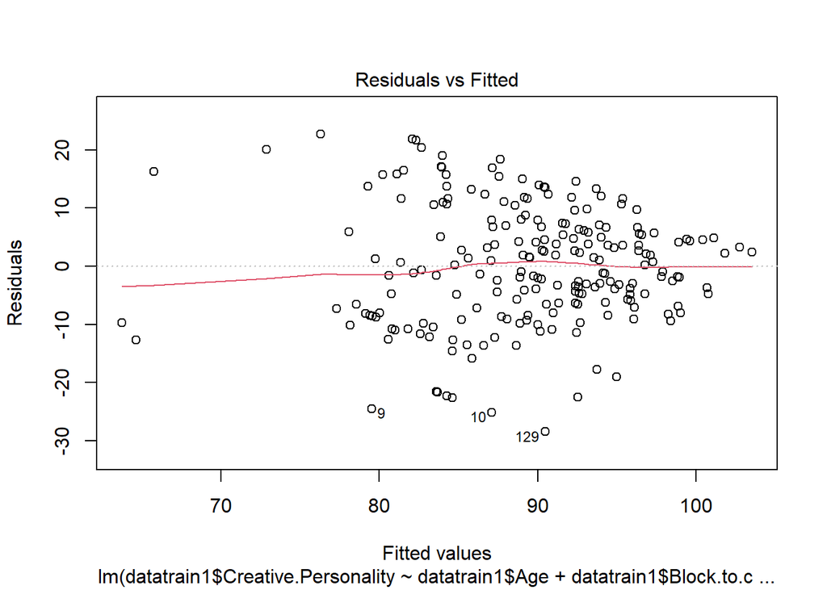

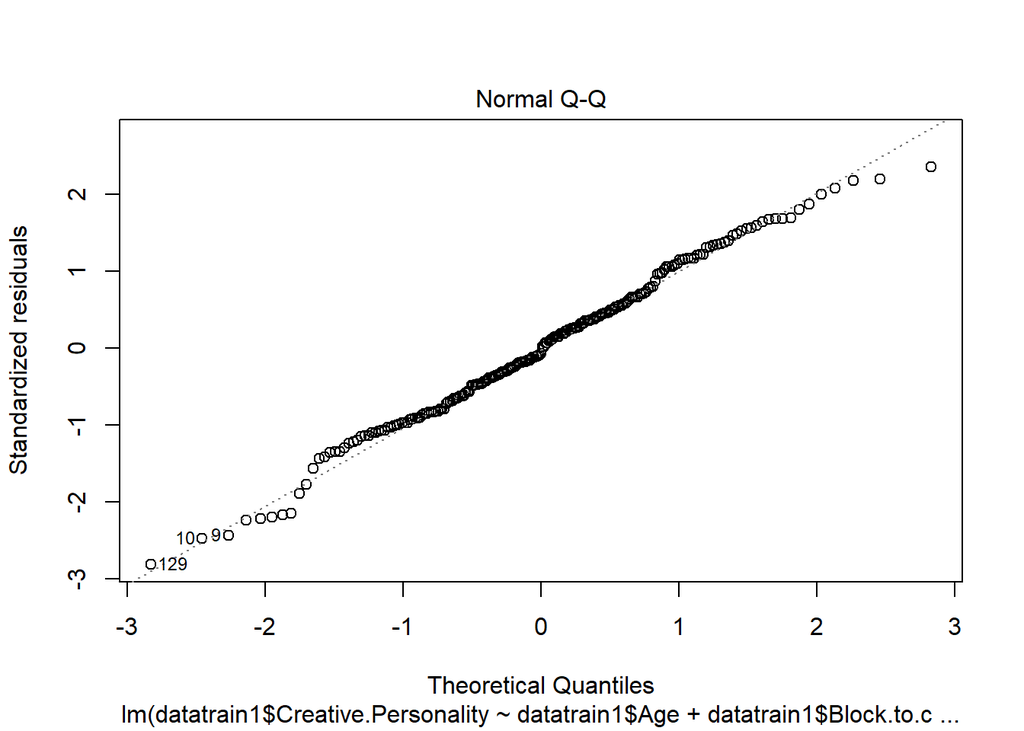

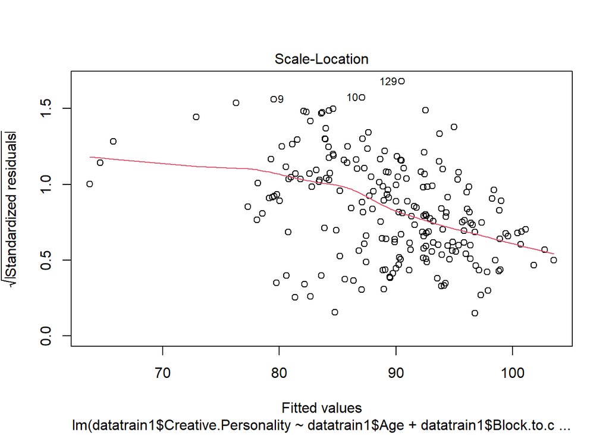

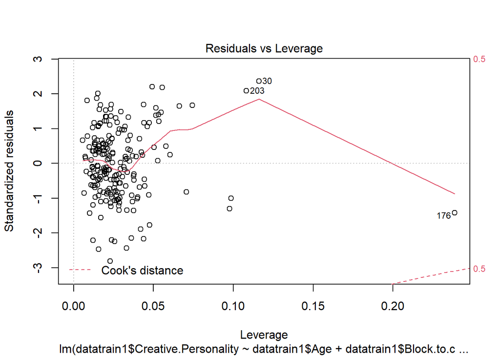

```r
plot(reg1)
```

```r
# checking multicolinearity
library(car)
vif(reg1)
```

```
##                                datatrain1$Age
##                                      1.082073
##                datatrain1$Block.to.creativity
##                                      1.017988
## datatrain1$Innovative.sponsoring.capabilities
##                                      1.632841
##                 datatrain1$Social.Environment
##                                      1.649851
##                   datatrain1$Work.environment
##                                      1.921397
```

```r
#auto correlation
library(lmtest)
dwtest(reg1)
```

```
##
##  Durbin-Watson test
##
## data:  reg1
## DW = 1.5622, p-value = 0.0005431
## alternative hypothesis: true autocorrelation is greater than 0
```

## the below code is to test normality of the given and formed regression model here from the graph we can say that they are normallyty distributed. Even in Shapiro test for the test of value being 0.99117 with the p value of 0.2226 greater than 0,5 says that the data of regression model is normally distributed

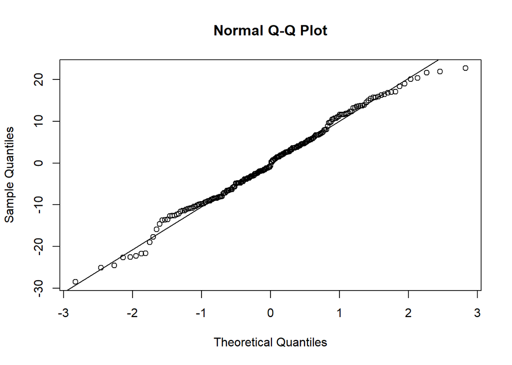

```r
# check normality of residual
qqnorm(reg1$residuals)
qqline(reg1$residuals)
```

```r
# test for normality
# h0 = data is  normally distributed
# h1 = data is not normally distributed
# shapiro test is used to test normality
shapiro.test(reg1$residuals)
```

```
##
##  Shapiro-Wilk normality test
##
## data:  reg1$residuals
## W = 0.99117, p-value = 0.2226
```

## Here for identifying the scatterness we use homo and hetro scadisticity, and here p value being less than 0.05 means the data leading to acceptance of alternate hypothesis of being the data of highly scattered

```r
#ho = data is homoscadisticity, means having the same scatter
# h1 = data is hetroscadisticity, means unequal scatter
bptest(reg1)
```

```
##
##  studentized Breusch-Pagan test
##
## data:  reg1
## BP = 35.574, df = 5, p-value = 1.156e-06
```

## Here the below code is used for finding the variation relaitonship between the rergession indepedednt and dependent variable, this can be find by checking the value of AIC

## The final data here provides the the final possible and best dataset for Backward regression model in annova

## here we have used MASS library to run Anova

```r
library(MASS)
regmodel = stepAIC(reg1, direction = "backward", trace = 1)
```

```
## Start:  AIC=996.11
## datatrain1$Creative.Personality ~ datatrain1$Age + datatrain1$Block.to.creativity +
##     datatrain1$Innovative.sponsoring.capabilities + datatrain1$Social.Environment +
##     datatrain1$Work.environment
##
##                                                 Df Sum of Sq   RSS     AIC
## - datatrain1$Innovative.sponsoring.capabilities  1      3.38 21627  994.14
## - datatrain1$Social.Environment                  1    138.43 21762  995.47
## <none>                                                       21623  996.11
## - datatrain1$Age                                 1    357.82 21981  997.61
## - datatrain1$Block.to.creativity                 1    528.32 22152  999.25
## - datatrain1$Work.environment                    1   2899.21 24523 1020.91
##
## Step:  AIC=994.14
## datatrain1$Creative.Personality ~ datatrain1$Age + datatrain1$Block.to.creativity +
##     datatrain1$Social.Environment + datatrain1$Work.environment
##
##                                  Df Sum of Sq   RSS     AIC
## - datatrain1$Social.Environment   1     157.9 21785  993.69
## <none>                                        21627  994.14
## - datatrain1$Age                  1     374.9 22002  995.80
## - datatrain1$Block.to.creativity  1     525.5 22152  997.26
## - datatrain1$Work.environment     1    3485.6 25112 1023.97
##
## Step:  AIC=993.69
## datatrain1$Creative.Personality ~ datatrain1$Age + datatrain1$Block.to.creativity +
##     datatrain1$Work.environment
##
##                                  Df Sum of Sq   RSS     AIC
## <none>                                        21785  993.69
## - datatrain1$Age                  1     356.3 22141  995.15
## - datatrain1$Block.to.creativity  1     480.7 22265  996.34
## - datatrain1$Work.environment     1    6789.7 28574 1049.48
```

```r
summary(regmodel)
```

```
##
## Call:
## lm(formula = datatrain1$Creative.Personality ~ datatrain1$Age +
##     datatrain1$Block.to.creativity + datatrain1$Work.environment)
##
## Residuals:
##      Min       1Q   Median       3Q      Max
## -29.3234  -7.3014  -0.3461   6.6665  22.1672
##
## Coefficients:
##                                Estimate Std. Error t value Pr(>|t|)
## (Intercept)                    46.49038   11.47831   4.050 7.21e-05 ***
## datatrain1$Age                  0.17723    0.09585   1.849   0.0659 .
## datatrain1$Block.to.creativity -0.18634    0.08677  -2.147   0.0329 *
## datatrain1$Work.environment     2.55766    0.31690   8.071 5.42e-14 ***
## ---
## Signif. codes:  0 '***' 0.001 '**' 0.01 '*' 0.05 '.' 0.1 ' ' 1
##
## Residual standard error: 10.21 on 209 degrees of freedom
## Multiple R-squared:  0.298,  Adjusted R-squared:  0.288
## F-statistic: 29.58 on 3 and 209 DF,  p-value: 5.568e-16
```

```r
regmodel$anova
```

```
## Stepwise Model Path
## Analysis of Deviance Table
##
## Initial Model:
## datatrain1$Creative.Personality ~ datatrain1$Age + datatrain1$Block.to.creativity +
##     datatrain1$Innovative.sponsoring.capabilities + datatrain1$Social.Environment +
##     datatrain1$Work.environment
##
## Final Model:
## datatrain1$Creative.Personality ~ datatrain1$Age + datatrain1$Block.to.creativity +
##     datatrain1$Work.environment
##
##
##                                              Step Df   Deviance Resid. Df
## 1                                                                     207
## 2 - datatrain1$Innovative.sponsoring.capabilities  1   3.376247       208
## 3                 - datatrain1$Social.Environment  1 157.929421       209
##   Resid. Dev      AIC
## 1   21623.40 996.1109
## 2   21626.77 994.1442
## 3   21784.70 993.6940
```

## Here the below code is used for finding the variation relaitonship between the rergession indepedednt and dependent variable, this can be find by checking the value of AIC

## The final data here provides the the final possible and best dataset for Forward regression model in annova

## the final best model suits for finding the relaitonship can be found using anova

```r
regmodel = stepAIC(reg1, direction = "forward", trace = 1)
```

```
## Start:  AIC=996.11
## datatrain1$Creative.Personality ~ datatrain1$Age + datatrain1$Block.to.creativity +
##     datatrain1$Innovative.sponsoring.capabilities + datatrain1$Social.Environment +
##     datatrain1$Work.environment
```

```r
summary(regmodel)
```

```
##
## Call:
## lm(formula = datatrain1$Creative.Personality ~ datatrain1$Age +
##     datatrain1$Block.to.creativity + datatrain1$Innovative.sponsoring.capabilities +
##     datatrain1$Social.Environment + datatrain1$Work.environment)
##
## Residuals:
##      Min       1Q   Median       3Q      Max
## -28.4664  -7.1541  -0.6809   6.6984  22.7069
##
## Coefficients:
##                                               Estimate Std. Error t value
## (Intercept)                                   42.40892   12.44592   3.407
## datatrain1$Age                                 0.17949    0.09698   1.851
## datatrain1$Block.to.creativity                -0.19631    0.08729  -2.249
## datatrain1$Innovative.sponsoring.capabilities  0.01472    0.08185   0.180
## datatrain1$Social.Environment                  0.47826    0.41546   1.151
## datatrain1$Work.environment                    2.24256    0.42568   5.268
##                                               Pr(>|t|)
## (Intercept)                                   0.000788 ***
## datatrain1$Age                                0.065625 .
## datatrain1$Block.to.creativity                0.025571 *
## datatrain1$Innovative.sponsoring.capabilities 0.857502
## datatrain1$Social.Environment                 0.250992
## datatrain1$Work.environment                   3.45e-07 ***
## ---
## Signif. codes:  0 '***' 0.001 '**' 0.01 '*' 0.05 '.' 0.1 ' ' 1
##
## Residual standard error: 10.22 on 207 degrees of freedom
## Multiple R-squared:  0.3032, Adjusted R-squared:  0.2864
## F-statistic: 18.02 on 5 and 207 DF,  p-value: 8.005e-15
```

```r
regmodel$anova
```

```
## Stepwise Model Path
## Analysis of Deviance Table
##
## Initial Model:
## datatrain1$Creative.Personality ~ datatrain1$Age + datatrain1$Block.to.creativity +
##     datatrain1$Innovative.sponsoring.capabilities + datatrain1$Social.Environment +
##     datatrain1$Work.environment
##
## Final Model:
## datatrain1$Creative.Personality ~ datatrain1$Age + datatrain1$Block.to.creativity +
##     datatrain1$Innovative.sponsoring.capabilities + datatrain1$Social.Environment +
##     datatrain1$Work.environment
##
##
##   Step Df Deviance Resid. Df Resid. Dev      AIC
## 1                        207    21623.4 996.1109
```

## Here the below code is used for finding relationship using both, forward and backward directions for the dataset in Anova

## The summary here tells the varaition with degree of fredom and with AIC

## The value of AIC here specifies how much good fit the data is

## We can consider the dataset of AIC having the low value

```r
regmodel = stepAIC(reg1, direction = "both", trace = 1)
```

```
## Start:  AIC=996.11
## datatrain1$Creative.Personality ~ datatrain1$Age + datatrain1$Block.to.creativity +
##     datatrain1$Innovative.sponsoring.capabilities + datatrain1$Social.Environment +
##     datatrain1$Work.environment
##
##                                                 Df Sum of Sq   RSS     AIC
## - datatrain1$Innovative.sponsoring.capabilities  1      3.38 21627  994.14
## - datatrain1$Social.Environment                  1    138.43 21762  995.47
## <none>                                                       21623  996.11
## - datatrain1$Age                                 1    357.82 21981  997.61
## - datatrain1$Block.to.creativity                 1    528.32 22152  999.25
## - datatrain1$Work.environment                    1   2899.21 24523 1020.91
##
## Step:  AIC=994.14
## datatrain1$Creative.Personality ~ datatrain1$Age + datatrain1$Block.to.creativity +
##     datatrain1$Social.Environment + datatrain1$Work.environment
##
##                                                 Df Sum of Sq   RSS     AIC
## - datatrain1$Social.Environment                  1     157.9 21785  993.69
## <none>                                                       21627  994.14
## - datatrain1$Age                                 1     374.9 22002  995.80
## + datatrain1$Innovative.sponsoring.capabilities  1       3.4 21623  996.11
## - datatrain1$Block.to.creativity                 1     525.5 22152  997.26
## - datatrain1$Work.environment                    1    3485.6 25112 1023.97
##
## Step:  AIC=993.69
## datatrain1$Creative.Personality ~ datatrain1$Age + datatrain1$Block.to.creativity +
##     datatrain1$Work.environment
##
##                                                 Df Sum of Sq   RSS     AIC
## <none>                                                       21785  993.69
## + datatrain1$Social.Environment                  1     157.9 21627  994.14
## - datatrain1$Age                                 1     356.3 22141  995.15
## + datatrain1$Innovative.sponsoring.capabilities  1      22.9 21762  995.47
## - datatrain1$Block.to.creativity                 1     480.7 22265  996.34
## - datatrain1$Work.environment                    1    6789.7 28574 1049.48
```

```r
summary(regmodel)
```

```
##
## Call:
## lm(formula = datatrain1$Creative.Personality ~ datatrain1$Age +
##     datatrain1$Block.to.creativity + datatrain1$Work.environment)
##
## Residuals:
##      Min       1Q   Median       3Q      Max
## -29.3234  -7.3014  -0.3461   6.6665  22.1672
##
## Coefficients:
##                                Estimate Std. Error t value Pr(>|t|)
## (Intercept)                    46.49038   11.47831   4.050 7.21e-05 ***
## datatrain1$Age                  0.17723    0.09585   1.849   0.0659 .
## datatrain1$Block.to.creativity -0.18634    0.08677  -2.147   0.0329 *
## datatrain1$Work.environment     2.55766    0.31690   8.071 5.42e-14 ***
## ---
## Signif. codes:  0 '***' 0.001 '**' 0.01 '*' 0.05 '.' 0.1 ' ' 1
##
## Residual standard error: 10.21 on 209 degrees of freedom
## Multiple R-squared:  0.298,  Adjusted R-squared:  0.288
## F-statistic: 29.58 on 3 and 209 DF,  p-value: 5.568e-16
```

```r
regmodel$anova
```

```
## Stepwise Model Path
## Analysis of Deviance Table
##
## Initial Model:
## datatrain1$Creative.Personality ~ datatrain1$Age + datatrain1$Block.to.creativity +
##     datatrain1$Innovative.sponsoring.capabilities + datatrain1$Social.Environment +
##     datatrain1$Work.environment
##
## Final Model:
## datatrain1$Creative.Personality ~ datatrain1$Age + datatrain1$Block.to.creativity +
##     datatrain1$Work.environment
##
##
##                                              Step Df   Deviance Resid. Df
## 1                                                                     207
## 2 - datatrain1$Innovative.sponsoring.capabilities  1   3.376247       208
## 3                 - datatrain1$Social.Environment  1 157.929421       209
##   Resid. Dev      AIC
## 1   21623.40 996.1109
## 2   21626.77 994.1442
## 3   21784.70 993.6940
```

```r
predict1 = predict(reg1,datatest1)
predict1
```

```
##         1         2         3         4         5         6         7         8
##  92.90435  95.37800  89.02651  81.55494  82.65031  82.30797  90.55688  83.41645
##         9        10        11        12        13        14        15        16
##  79.50593  87.10179  84.87818  82.59207  90.98097  83.66472  90.06803  94.58452
##        17        18        19        20        21        22        23        24
##  96.83607  94.11178  93.89825  83.16986  95.37795  90.02272  96.36471  84.25949
##        25        26        27        28        29        30        31        32
## 103.52279  96.55470  88.05450  81.79859  65.76347  76.29315  92.52911  85.84770
##        33        34        35        36        37        38        39        40
##  79.75880  80.01247  93.20251  93.13467  92.63714  94.81042  89.45274  85.21072
##        41        42        43        44        45        46        47        48
## 101.82122  92.36436  90.14682  95.67292  98.90313  96.30158  79.12531  92.60345
##        49        50        51        52        53        54        55        56
##  85.60144  93.99221  98.83200  97.80498  92.45090  98.85746  97.33994  97.10538
##        57        58        59        60        61        62        63        64
##  92.41650  95.84305  96.36870  84.27702  99.03772  98.92706  99.39325  92.52086
##        65        66        67        68        69        70        71        72
##  90.00938  92.16348  93.60582  90.25231  91.58326  96.77319  93.89600 100.41870
##        73        74        75        76        77        78        79        80
##  89.49899  97.28042  92.79134  93.08877  92.34444  93.19560  98.41361  92.37290
##        81        82        83        84        85        86        87        88
## 101.10277  89.14789  95.88605  86.60387  91.25379  87.70871  94.44707  96.27257
##        89        90        91        92        93        94        95        96
##  94.41900  95.84589  89.13506  92.45090  89.23097  94.86455  93.53928  96.75521
##        97        98        99       100       101       102       103       104
##  94.27064  89.36518  94.00170  91.17311  91.75039  64.62841  92.69631  82.16939
##       105       106       107       108       109       110       111       112
##  88.70577  88.65874  89.31973  85.53839  81.34292  86.15410  89.73159  84.32770
##       113       114       115       116       117       118       119       120
##  85.82283  91.11577  89.06433  90.65546  96.40806  92.25001  81.00437  90.40680
##       121       122       123       124       125       126       127       128
##  88.87358  92.63062  90.22731  91.33574  79.42180  87.05458  84.75866  82.77156
##       129       130       131       132       133       134       135       136
##  90.46638  84.24163  82.68092  89.90520  82.07118  87.13599  78.55974  79.29986
##       137       138       139       140       141       142       143       144
##  87.27727  92.33721  99.61899  89.88607  90.38330  87.43421  92.59065  81.11752
##       145       146       147       148       149       150       151       152
##  88.96074  90.44746  63.74568  85.17941  78.08319  84.62281  80.59454  83.87390
##       153       154       155       156       157       158       159       160
##  88.95575  87.85303  84.22730  80.76178  84.61932  94.32285  93.91473  97.90154
##       161       162       163       164       165       166       167       168
## 100.78714  94.22706  78.17841  83.45815  95.12528  93.73052  94.98695  92.37257
##       169       170       171       172       173       174       175       176
##  87.43383  89.99854  79.81122  87.30084  86.80685  77.31613  79.54344  84.65166
##       177       178       179       180       181       182       183       184
##  90.29761  84.00059  90.47714  93.71213  83.90372  91.55845  81.36831  83.95952
##       185       186       187       188       189       190       191       192
## 102.75996 100.69803  96.09117  88.89995  95.29885  89.40175  98.25536  83.42012
##       193       194       195       196       197       198       199       200
##  83.59822  86.35789  87.64694  83.59284  87.54491  80.81399  92.57384  88.79290
##       201       202       203       204       205       206       207       208
##  87.97193  87.18706  72.87640  96.07683  87.08670  95.99366  90.89099  86.68239
##       209       210       211       212       213
##  80.56372  84.02867  98.52237  80.22732  88.57843
```

```r
str(predict1)
```

```
##  Named num [1:213] 92.9 95.4 89 81.6 82.7 ...
##  - attr(*, "names")= chr [1:213] "1" "2" "3" "4" ...
```

## AIC and BIC are also penalized-likelihood criteria, as we all know. In a given Bayesian setup, BIC is an approximation of a function of the posterior likelihood of a model being valid, with a lower BIC indicating that a model is more likely to be the true model. This shows the output of the likelyness of the dataset as much low the dataset is the better the dataset

```r
AIC(reg1)
```

```
## [1] 1602.579
```

```r
BIC(reg1)
```

```
## [1] 1626.108
```

## In terms of Ethics from the dataset we can say that Ethics should be followed in work environment, and in creating new ways of doing works, The company or organization should encourage people in creativity and should be allowed ethically to take a step in creating